# SIFS minimal reproducible example

Shad Arif Mohammed

2026-04-23

# install and load SIFS package

- please install the dependencies if not installed already (see Description file).

`Description`

This is an end to end pipeline in R to perform SIFS workflow on two tissue samples. One would be considered as training set tissue {XIII-t3 83318 (ref tissue num = t3)} and the other is testing set tissue {XV_t1 82558 (ref tissue num = t4)} sample.

```r
# install.packages("remotes")
if(!"SIFS" %in% rownames(installed.packages())){
  print("The SIFS package is not installed on your System, yet!")
  remotes::install_github("CeMOS-Mannheim/SIFS")

  } else{print("The SIFS package is already available.")}
```

```
#> [1] "The SIFS package is already available."
```

```r
library(SIFS)
```

## Instantiate required variables

needed variables Are: {input, output, ionization, Alpha, ROIs, comparisonNum, current_data, mzMode, selectedmzList}

```r
# [0] globally important variables
root_dir = file.path("D:/Projects/Rpackages/SIFS/")
# I/O of this project:

in_project  = file.path("data/", "input") # files to be used as inputs.
out_project = file.path("data/output/")   # files to be used as intermediate outputs.


## set alpha for transparency control of multimodal integration
Alpha = 0.5

## set a date stamp to be put in output file names and folder structure names:
current_date = format(Sys.time(), "%d_%m_%y")
print(current_date)
```

```
#> [1] "23_04_26"
```

```r
# _____________________________________
# [1] variables needed to load msi dataset (spmat, coords, mis files), optical image, and H&E image
# _____________________________________
ionisation = c("pos","neg")
selected_ionisation = ionisation[1]
ROIs <- c("VT","Nec","PreNec")
ROI = ROIs[1]
# condition to select the name of comparison iter:
num_comparison = NA
if(ROI == "VT"){
      num_comparison = "01"
}else if(ROI == "Nec"){
      num_comparison = "02"
}else {num_comparison = "03"
}



absPath = root_dir # path to project directory:
# root dir for the different inputs:

input_main = file.path(absPath, "data/input")
output_main <- switch(selected_ionisation,
                      "pos" = {
                          dir_path <- file.path(absPath, "data/output", "01_pos", "12_multimodalIntgrtion_mz")
                          if (!file.exists(dir_path)) dir.create(dir_path, recursive = TRUE)
                          dir_path
                      },
                      "neg" = {
                          dir_path <- file.path(absPath, "data/output", "02_neg", "12_multimodalIntgrtion_mz")
                          if (!file.exists(dir_path)) dir.create(dir_path, recursive = TRUE)
                          dir_path
                      },
                      message("The selected ionisation is not known!"))

# _____________________________________
# [2] variables needed for SHAP and SHAP filtering
# _____________________________________

mzModes     <- c("02_SIFS_outputs","01_SHAP_outputs")
sel_mzModes <- mzModes[1] # select the SIFS outputs here.
cat("selection mode is of this iteration is : ",sel_mzModes, "\n selected ROI is: ", ROI)
```

```
#> selection mode is of this iteration is :  02_SIFS_outputs
#>  selected ROI is:  VT
```

```r
# here plot top 10 pos and/or neg shap values, for that I am making new selections
SelSHAP = c("PosSHAP", "NegSHAP")[1]

if(SelSHAP == "PosSHAP"){
       mzList = c()} else{
       mzList = c()}
cat("the selected m/z list for this workflow is: \n",mzList)
```

```
#> the selected m/z list for this workflow is:
```

```r
print(mzList)
```

```r
# _____________________________________
# [3] variables needed for multimodal integration
# _____________________________________

# all tissue names in both cohorts:
t_names = paste0("t",seq(1,32)[-c(6,21,23)]) # why tissue 6 is excluded here ? in the refernce num tissue 6 is XIII-t3 83318 but here I must check.
trainSetNames = paste0("t",seq(1,32)[-c(1,4,5,18,6,21,23,20,22,24,25,26,27,28)])
testSetNames  = t_names[!t_names%in%trainSetNames]

# Requirement 1) load mis files, so as to get tissue boundary and annotations if needed.

TrainingSetMis = file.path(absPath, "data/input", "0_mis_files/mis_XIII_t3_83318_trainSet.rds") # training set mis file:
TestingSetMis  = file.path(absPath, "data/input", "0_mis_files/mis_XV_t2_82558_testSet.rds")

## read mis files below, from RDS files:
t3_mis   <- readRDS(file = TrainingSetMis) # this reads Training Set mis file.
t4_mis    <- readRDS(file = TestingSetMis)  # this reads Testing  Set mis file.

# names_mis <- paste0("t", seq(42)[-c(6,21,23)])



# names(mis_pos) <- names_mis; rm(names_mis)
# after extracting the needed mis files then remove the global one:


# remove mis files here, to save memory:


# clear up RAM
gc(full = TRUE)
```

```
#>           used  (Mb) gc trigger  (Mb) max used  (Mb)
#> Ncells 2897802 154.8    5926761 316.6  2914238 155.7
#> Vcells 8491074  64.8   12282534  93.8  8533177  65.2
```

# Set ROI names of the tissue samples:

here you would need to get the ROI names of the tissue samples you need for the analysis, as each measurement slide contains several tissue samples on them, and one would need to know exactly which tissue ROI names should pick. Dataset meta data are provided in the Data-sets repository on Zenodo.org under the following DOI:

10.5281/zenodo.18187395

```r
TrainingSetROI_name <- "83318"
TestingSetROI_name  <- "82558"
```

# Save mis files of t3 and t4 to input

```r
# t3 = XIII-t3 83318 == training set tissue
# saveRDS(object = mis_pos$t3, file = file.path(in_project, "0_mis_files", "mis_XIII_t3_83318_trainSet.rds"))
# t4 = XV-t1 82558 == testing set tissue
# saveRDS(object = mis_pos$t4, file = file.path(in_project, "0_mis_files", "mis_XV_t2_82558_testSet.rds"))
```

# Load inputs

## load inputs first, then deposit them to the input of this project

```r
# path to a folder where the input files can be found [pre-processed]:
AbsPath  = absPath

# Read sparse intensity matrices (SPMAT objects):

# 01: spmat for training set (t3)
t3_spmat_pos <- readRDS(file = file.path(AbsPath, "data/input/01_spmatObjects/trainset_tissue/tr_spmat_XIII_t3_83318.rds"))
# 02: spmat for testing set (t4)
t4_spmat_pos <- readRDS(file = file.path(AbsPath, "data/input/01_spmatObjects/testset_tissue/tst_spmat_XV_t1_82558.rds"))




# Read labels and split by tissue sample:
# Read in all labels for all tissues, not needed for this example workflow:
lbls_pos_ALL  <- readRDS(file = file.path(AbsPath, "data/input/04_y_lbls/spectraLblsAll/04_Lbl_df_giant_pos/Lbls_df_Pos_all.rds"))
# Define a function to create coordinates matrix for each patient:

split_lbls <- split(lbls_pos_ALL, lbls_pos_ALL$pos_refNames)

# Note: Label encoding is: 0 == Tumor , 1 == No-tumor

# Obtain t3 labels:
t3_lbls <- as.factor(split_lbls$t3$Vt_vs_all_lbls)

# Obtain t4 labels:
t4_lbls <- as.factor(split_lbls$t4$Vt_vs_all_lbls)


# get pixel coordinates for each
t3_coordinatesDF <- split_lbls$t3[,11:12] # for training set.
t4_coordinatesDF <- split_lbls$t4[,11:12] # for testing  set.

lbls_pos = lbls_pos_ALL
```

# Labels of TrainSet TestSet

labels must be extracted from .mis files, then vectorised, this workflow shows already vectorized labels:

```r
# lbls_pos$pos_refNames %>% table()
# [ROI options]: "VT"     "Nec"    "PreNec"



if(ROI == "VT"){
      # XIII-t3 83318 TrainingSet lables:
      t3_lbls = lbls_pos$Vt_vs_all_lbls[lbls_pos$pos_refNames == "t3"]
      # XV-t1 82558 TestingSet lables:
      t4_lbls = lbls_pos$Vt_vs_all_lbls[lbls_pos$pos_refNames == "t4"]
}else if(ROI == "Nec"){
      # XIII-t3 83318 TrainingSet lables:
      t3_lbls = lbls_pos$Nec_vs_all_lbls[lbls_pos$pos_refNames == "t3"]
      # XV-t1 82558 TestingSet lables:
      t4_lbls = lbls_pos$Nec_vs_all_lbls[lbls_pos$pos_refNames == "t4"]

}else if(ROI == "PreNec"){
      # XIII-t3 83318 TrainingSet lables:
      t3_lbls = lbls_pos$PreNec_vs_all_lbls[lbls_pos$pos_refNames == "t3"]
      # XV-t1 82558 TestingSet lables:
      t4_lbls = lbls_pos$PreNec_vs_all_lbls[lbls_pos$pos_refNames == "t4"]
}else{cat("lbl class not known .... Please add your other label class conditions here !")}
```

# Deposit processed SPMAT to input directory

SPMAT stands for sparse intensity matrix, for faster computation.

- save SPMAT of t3 and t4 in the input folder then reload them.

```r
# training set tissue sample saved:
# saveRDS(object = spmat_pos_list$t3, file.path(in_project,"01_spmatObjects", "trainset_tissue", "tr_spmat_XIII_t3_83318.rds"))
# test set tissue sample saved:
# saveRDS(object = spmat_pos_list$t4, file.path(in_project,"01_spmatObjects", "testset_tissue", "tst_spmat_XV_t1_82558.rds"))

# read trainset SPMAT object:
# t3_spmat = readRDS(file = file.path(in_project,"01_spmatObjects", "trainset_tissue", "tr_spmat_XIII_t3_83318.rds"))
# # read test set SPMAT object:
# t4_spmat = readRDS(file = file.path(in_project,"01_spmatObjects", "testset_tissue", "tst_spmat_XV_t1_82558.rds"))
# gc(full = TRUE)
```

# Recheck thoroughly:

```r
# Run python chunks:

## - Run SHAP pipeline from R
# install.packages("xgboost")
# [02] Load needed R libraries
library(xgboost)
# library(shapr) # install using: install.packages("shapr")
library(data.table)
library(Matrix)

# Convert labels to numeric (0/1)
y_train <- as.numeric(t3_lbls) #- 1  # Convert from 1/2 to 0/1
y_test <- as.numeric(t4_lbls) #- 1

# Check label distribution
cat("Training labels table:\n")
```

```
#> Training labels table:
```

```r
print(table(y_train))
```

```
#> y_train
#>    0    1
#>  823 2837
```

```r
cat("Test labels table:\n")
```

```
#> Test labels table:
```

```r
print(table(y_test))
```

```
#> y_test
#>    0    1
#> 7232 6268
```

```r
# Convert sparse matrix to dense matrix
X_train <- as.matrix(t3_spmat_pos[["spmat"]])
X_test <- as.matrix(t4_spmat_pos[["spmat"]])
# Check for any issues
cat("X_train dimensions:", dim(X_train), "\n")
```

```
#> X_train dimensions: 3660 13144
```

```r
cat("X_test dimensions:", dim(X_test), "\n")
```

```
#> X_test dimensions: 13500 13144
```

```r
cat("Any NA in X_train:", anyNA(X_train), "\n")
```

```
#> Any NA in X_train: FALSE
```

```r
cat("Any NA in y_train:", anyNA(y_train), "\n")
```

```
#> Any NA in y_train: FALSE
```

# The following code snippet requires ML and XAI knowledge

– Adapt accordingly.

# 3) train xgboost

- Create intensity matrices out of the “trainSet” and “testSet” objects.
- Split the spectra from training set into train and validation sub-sets. Then, train the model and test on the validation set.

```r
# creaet sparse matrix from trainSet and testSet objects.
# trainSet_spmat <- moleculaR::createSparseMat(trainSet)
# testSet_spmat  <- moleculaR::createSparseMat(testSet)
trainSet_spmat <- t3_spmat_pos  # this is the sparse intensity matrix of the training set: 23.04.2026
testSet_spmat  <- t4_spmat_pos
gc(full = T)
```

```
#>             used   (Mb) gc trigger   (Mb)  max used   (Mb)
#> Ncells   3980221  212.6    5926761  316.6   5926761  316.6
#> Vcells 289602411 2209.5  419614665 3201.5 289796315 2211.0
```

### checkPpoint directory

_______________________ CheckPoint _______________________

```r
# Checkpoint directory:
checkPointDir <- AbsPath

# save processed and extracted sparse matrices:
saveRDS(object = trainSet_spmat, file = file.path(checkPointDir, "data/input/trainSet_spmat.rds"))
saveRDS(object = testSet_spmat, file = file.path(checkPointDir, "data/input/testSet_spmatSet_spmat.rds"))
saveRDS(object = trainSet_spmat$mzAxis, file = file.path(checkPointDir, "data/input/colNames.rds"))

gc(full= TRUE)
```

```
#>             used   (Mb) gc trigger   (Mb)  max used   (Mb)
#> Ncells   3980307  212.6    5926761  316.6   5926761  316.6
#> Vcells 289602603 2209.5  419614665 3201.5 289796315 2211.0
```

### ReLoad:

```r
# reload all the components needed:
checkPointDir <- AbsPath
trainSet_spmat <- readRDS(file.path(checkPointDir, "data/input/trainSet_spmat.rds"))
testSet_spmat  <- readRDS(file.path(checkPointDir, "data/input/testSet_spmatSet_spmat.rds"))
colNames       <- readRDS(file.path(checkPointDir, "data/input/colNames.rds"))

# Also reload original spmat objects for spatial window creation
t3_spmat_pos <- readRDS(file = file.path(checkPointDir, "data/input/01_spmatObjects/trainset_tissue/tr_spmat_XIII_t3_83318.rds"))
t4_spmat_pos <- readRDS(file = file.path(checkPointDir, "data/input/01_spmatObjects/testset_tissue/tst_spmat_XV_t1_82558.rds"))

message("Reload chunk: t3_spmat_pos loaded: ", exists("t3_spmat_pos"), ", t4_spmat_pos loaded: ", exists("t4_spmat_pos"))
```

```
#> Reload chunk: t3_spmat_pos loaded: TRUE, t4_spmat_pos loaded: TRUE
```

# get labels for the training set:

```r
library(dplyr)
# the training set tissue sample here is referebced as "t3"
## find index of training set labels:
index_lbls <- which(lbls_pos_ALL$pos_refNames == "t3")
# extract tissue 3 as the training set labels:

Subset_labelsDF <- lbls_pos_ALL[index_lbls, ]

binary_t1_lbls <- Subset_labelsDF$Vt_vs_all_lbls
binary_t1_lbls <- as.numeric(as.character(binary_t1_lbls))
# the length of this labels vector for this tissue sample : 3660 pixels
```

## create dense matrices with their mz value names:

```r
# get column names:
mz_trainSet <- trainSet_spmat$mzAxis
mz_testSet  <- testSet_spmat$mzAxis
# Get the SPMAT objects out:
trainMat      <- trainSet_spmat$spmat
testMat       <- testSet_spmat$spmat
# Convert to dense matrices :-
trainMat <- Matrix::as.matrix(trainMat)
testMat  <- Matrix::as.matrix(testMat)
gc(full = T)
```

```
#>             used   (Mb) gc trigger   (Mb)  max used   (Mb)
#> Ncells   4141175  221.2    7692300  410.9   5926761  316.6
#> Vcells 563147403 4296.5  813524188 6206.7 563166109 4296.7
```

## add labels to trainMat

```r
# the following creates a new that has the labels at the last column.
trainMat <- cbind(trainMat, binary_t1_lbls)
```

- install caret –> install.packages(“caret”, dependencies = c(“Depends”, “Suggests”))
- split to 20% by 80% samples

# convert training matrix to dataframe:

```r
trainMat <- as.data.frame(trainMat)
colNames <- c(mz_trainSet, "target")
colnames(trainMat) <- colNames


gc(full = TRUE)
```

```
#>             used   (Mb) gc trigger   (Mb)  max used   (Mb)
#> Ncells   4181346  223.4    7692300  410.9   5926761  316.6
#> Vcells 563307138 4297.7  813524188 6206.7 684001938 5218.6
```

```r
library(caret)
# 'trainMat' is training data set and the last column is the target variable
set.seed(123)  # For reproducibility
splitIndex <- createDataPartition(trainMat$target, p = 0.8, list = FALSE)

# Split the data into training and validation sets
train_data <- trainMat[splitIndex, ]
validation_data <- trainMat[-splitIndex, ]

gc()
```

```
#>             used   (Mb) gc trigger   (Mb)  max used   (Mb)
#> Ncells   4985570  266.3    7692300  410.9   7692300  410.9
#> Vcells 612691350 4674.5  976309025 7448.7 684001938 5218.6
```

# Convert to Numeric feature matrix

the above processing converts the feature matrix to str, now they must be converted back to numeric values.

```r
library(dplyr)
# the following does the conversion:
train_data <- mutate_all(train_data, function(x) as.numeric(as.character(x)))
validation_data <- mutate_all(validation_data, function(x) as.numeric(as.character(x)))

gc(full = T)
```

```
#>             used   (Mb) gc trigger   (Mb)  max used   (Mb)
#> Ncells   5032803  268.8    9375849  500.8   9375849  500.8
#> Vcells 614726204 4690.0  976309025 7448.7 765105610 5837.3
```

```r
# Convert datasets to xgboost's DMatrix format
train_label       <- train_data$target
train_matrix      <- xgb.DMatrix(data = as.matrix(train_data %>% select(-target)), label = train_label)

validation_label  <- validation_data$target
validation_matrix <- xgb.DMatrix(data = as.matrix(validation_data %>% select(-target)), label = validation_label)
```

# Free space:

remove duplicated variables that are no-longer needed.

```r
rm(t3_spmat_pos, t3_mis, t4_mis, t4_spmat_pos, Train_data_, testSet_spmat, testMat, trainMat, trainSet_spmat, X_test)
gc(full = TRUE)
```

```
#>             used   (Mb) gc trigger   (Mb)  max used   (Mb)
#> Ncells   2670422  142.7    7500680  400.6   9375849  500.8
#> Vcells 157064282 1198.4  781047220 5959.0 765105610 5837.3
```

## Define Hyperparameter Tuning Grid

```r
# # Define a grid of hyperparameters for tuning
# xgb_grid <- expand.grid(
#   nrounds = c(100, 200),              # Number of boosting rounds
#   eta = c(0.01, 0.1, 0.3),            # Learning rate
#   max_depth = c(3, 6, 9),             # Depth of trees
#   gamma = c(0, 0.1, 0.3),             # Minimum loss reduction
#   colsample_bytree = c(0.6, 0.8, 1),  # Column sampling by tree
#   min_child_weight = c(1, 3, 5),      # Minimum sum of instance weight
#   subsample = c(0.5, 0.7, 1)          # Subsample ratio
# )
```

## Define xgboost Training Control

```r
# train_control <- trainControl(
#   method = "cv",                # Cross-validation method
#   number = 5,                   # 5-fold cross-validation
#   verboseIter = TRUE,           # Show training progress
#   allowParallel = TRUE          # Allow parallel processing if available
# )
```

## Train the model

```r
# Train the model with hyperparameter tuning
# xgb_tune <- train(
#   x = as.matrix(train_data %>% select(-target)),  # Features
#   y = train_data$target,                          # Target variable
#   trControl = train_control,                      # Cross-validation settings
#   tuneGrid = xgb_grid,                            # Hyperparameter grid
#   method = "xgbTree",                             # xgboost method
#   verbose = TRUE,                                  # Enable verbosity
#   objective = "binary:logistic"
#
#   )
```

## Best hyper parameters:

nrounds = 200 max_depth = 6 eta = 0.1 gamma = 0 colsample_bytree = 0.6 min_child_weight = 3 subsample = 1

## train a final model with binary:logisic param

- the xgboost outputs were based on regression, which is not the same as prediction probabilities:

```r
library(xgboost)

# Ensure matrix format
X <- as.matrix(train_data[, setdiff(names(train_data), "target")])
y <- as.numeric(as.character(train_data$target))  # must be 0/1, ensure numeric

dtrain <- xgb.DMatrix(data = X, label = y)

params <- list(
  objective = "binary:logistic",
  max_depth = 6,
  eta = 0.1,
  gamma = 0,
  colsample_bytree = 0.6,
  min_child_weight = 3,
  subsample = 1,
  eval_metric = "logloss"
)

model <- xgb.train(
  params = params,
  data = dtrain,
  nrounds = 200
)
```

# 1. Evaluation (Updated for xgboost)

```r
# Ensure target is numeric 0/1
validation_y <- as.numeric(as.character(validation_data$target))

# Build feature matrix (exclude target)
validation_matrix <- as.matrix(
  validation_data[, setdiff(colnames(validation_data), "target")]
)

dvalid <- xgb.DMatrix(data = validation_matrix)

# Predict probabilities
validation_pred_prob <- predict(model, dvalid)

# Binarize at 0.5 threshold
validation_pred_binary <- ifelse(validation_pred_prob >= 0.5, 1, 0)

# Convert to factor for confusionMatrix
# library(caret)

confusionMatrix(
  factor(validation_pred_binary, levels = c(0,1)),
  factor(validation_y, levels = c(0,1))
)
```

```
#> Confusion Matrix and Statistics
#>
#>           Reference
#> Prediction   0   1
#>          0 159  16
#>          1   5 552
#>
#>                Accuracy : 0.9713
#>                  95% CI : (0.9565, 0.9822)
#>     No Information Rate : 0.776
#>     P-Value [Acc > NIR] : <2e-16
#>
#>                   Kappa : 0.9194
#>
#>  Mcnemar's Test P-Value : 0.0291
#>
#>             Sensitivity : 0.9695
#>             Specificity : 0.9718
#>          Pos Pred Value : 0.9086
#>          Neg Pred Value : 0.9910
#>              Prevalence : 0.2240
#>          Detection Rate : 0.2172
#>    Detection Prevalence : 0.2391
#>       Balanced Accuracy : 0.9707
#>
#>        'Positive' Class : 0
#>
```

# 2. Save the Model

```r
# Save full model object
saveRDS(model, file = file.path(checkPointDir, "data/input/best_xgboost_model.rds"))

# Optional: save in native xgboost binary format (more portable)
xgb.save(model, file.path(checkPointDir, "data/input/best_xgboost_model.bin"))
```

```
#> [1] TRUE
```

# 3. ROC + AUC (Plots)

```r
library(pROC)
```

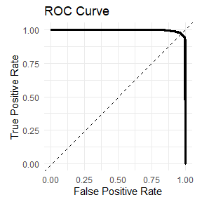

```r
library(ggplot2)

roc_curve <- roc(validation_y, validation_pred_prob)
# Create ROC dataframe
roc_data <- data.frame(
  FPR = rev(roc_curve$specificities),
  TPR = rev(roc_curve$sensitivities),
  thresholds = rev(roc_curve$thresholds)
)

roc_plot <- ggplot(roc_data, aes(x = FPR, y = TPR)) +
  geom_line(size = 1.2) +
  geom_abline(intercept = 0, slope = 1, linetype = "dashed") +
  labs(
    title = "ROC Curve",
    x = "False Positive Rate",
    y = "True Positive Rate"
  ) +
  theme_minimal() +
  coord_fixed() +
  xlim(0,1) +
  ylim(0,1)
print(roc_plot)
```

```r
cat("AUC:", auc(roc_curve), "\n")
```

```
#> AUC: 0.9966721
```

# XAI chunks:

## 1) SHAP computation (unified, corrected)

```r
# --- Libraries ---
library(treeshap)
library(xgboost)
library(ggplot2)
library(data.table)

xai_feature_cols <- setdiff(names(train_data), "target")
xai_train_df <- train_data[, xai_feature_cols, drop = FALSE]
xai_train_matrix <- as.matrix(xai_train_df)
xai_train_idx <- as.integer(splitIndex)
roi_label_map <- c(
  VT = "Vt_vs_all_lbls",
  Nec = "Nec_vs_all_lbls",
  PreNec = "PreNec_vs_all_lbls"
)
shap_output_root <- file.path(AbsPath, "output/SHAP_outputs")

dir.create(shap_output_root, recursive = TRUE, showWarnings = FALSE)

xai_xgb_params <- list(
  objective = "binary:logistic",
  max_depth = 6,
  eta = 0.1,
  gamma = 0,
  colsample_bytree = 0.6,
  min_child_weight = 3,
  subsample = 1,
  eval_metric = "logloss"
)
xai_nrounds <- 200L
roi_shap_results <- list()

xai_unify_xgboost <- function(xgb_model, data) {
  xgbtree <- xgboost::xgb.model.dt.tree(model = xgb_model)

  if (!("Gain" %in% colnames(xgbtree)) && "Quality" %in% colnames(xgbtree)) {
    xgbtree$Gain <- xgbtree$Quality
  }

  stopifnot(
    c(
      "Tree", "Node", "ID", "Feature", "Split",
      "Yes", "No", "Missing", "Gain", "Cover"
    ) %in% colnames(xgbtree)
  )

  xgbtree$Yes <- match(xgbtree$Yes, xgbtree$ID)
  xgbtree$No <- match(xgbtree$No, xgbtree$ID)
  xgbtree$Missing <- match(xgbtree$Missing, xgbtree$ID)
  xgbtree[is.na(xgbtree$Split), "Feature"] <- NA_character_
  xgbtree$Decision.type <- factor(rep("<=", nrow(xgbtree)), levels = c("<=", "<"))
  xgbtree$Decision.type[is.na(xgbtree$Feature)] <- NA_character_
  xgbtree <- xgbtree[, c(
    "Tree", "Node", "Feature", "Decision.type", "Split",
    "Yes", "No", "Missing", "Gain", "Cover"
  )]
  colnames(xgbtree) <- c(
    "Tree", "Node", "Feature", "Decision.type", "Split",
    "Yes", "No", "Missing", "Prediction", "Cover"
  )
  xgbtree$Prediction[!is.na(xgbtree$Feature)] <- NA_real_

  feature_names <- tryCatch(
    xgboost::getinfo(xgb_model, "feature_name"),
    error = function(e) NULL
  )
  if (is.null(feature_names) || !length(feature_names)) {
    feature_names <- colnames(data)
  }

  if (all(feature_names %in% colnames(data))) {
    data <- data[, feature_names, drop = FALSE]
  }

  unified_model <- list(
    model = as.data.frame(xgbtree),
    data = as.data.frame(data),
    feature_names = feature_names
  )
  class(unified_model) <- "model_unified"
  attr(unified_model, "missing_support") <- TRUE
  attr(unified_model, "model") <- "xgboost"
  unified_model
}

for (roi_name in ROIs) {
  raw_labels <- as.character(Subset_labelsDF[[roi_label_map[[roi_name]]]][xai_train_idx])

  if (length(unique(raw_labels)) < 2) {
    message(
      "Skipping ", roi_name,
      " SHAP because only one raw class is present in the training split."
    )
    next
  }

  target_is_roi <- ifelse(raw_labels == "1", 1L, 0L)
  roi_dtrain <- xgb.DMatrix(
    data = xai_train_matrix,
    label = target_is_roi
  )

  roi_model <- xgb.train(
    params = xai_xgb_params,
    data = roi_dtrain,
    nrounds = xai_nrounds,
    verbose = 0
  )

  roi_unified_model <- tryCatch(
    treeshap::unify(roi_model, xai_train_df),
    error = function(e) {
      message(
        "Using xgboost compatibility unifier for ", roi_name,
        ": ", conditionMessage(e)
      )
      xai_unify_xgboost(roi_model, xai_train_df)
    }
  )
  roi_treeshap <- treeshap::treeshap(
    roi_unified_model,
    xai_train_df,
    verbose = FALSE
  )

  target_rows <- target_is_roi == 1L
  target_shaps <- roi_treeshap$shaps[target_rows, , drop = FALSE]
  mean_target_shap <- colMeans(target_shaps)
  mz_values <- as.numeric(names(mean_target_shap))

  roi_output_dir <- file.path(shap_output_root, paste0(roi_name, "_SHAPs"))
  dir.create(roi_output_dir, recursive = TRUE, showWarnings = FALSE)

  positive_shap_df <- data.table(
    mz_list = mz_values,
    Pos_Shaps = as.numeric(mean_target_shap)
  )[order(-Pos_Shaps)]

  negative_shap_df <- data.table(
    mz_list = mz_values,
    Neg_Shaps = as.numeric(mean_target_shap)
  )[order(Neg_Shaps)]

  data.table::fwrite(
    positive_shap_df,
    file = file.path(
      roi_output_dir,
      paste0("PostiveSHAP_value_", roi_name, "_DF_lbl.csv")
    )
  )
  data.table::fwrite(
    negative_shap_df,
    file = file.path(
      roi_output_dir,
      paste0("NegativeSHAP_value_", roi_name, "_DF_lbl.csv")
    )
  )

  roi_shap_results[[roi_name]] <- list(
    target_rows = target_rows,
    target_shaps = target_shaps,
    target_values = xai_train_df[target_rows, , drop = FALSE],
    mean_target_shap = mean_target_shap,
    roi_output_dir = roi_output_dir
  )

  message("Saved SHAP outputs for ", roi_name, " to ", roi_output_dir)
}
```

```
#> Saved SHAP outputs for VT to D:/Projects/Rpackages/SIFS/output/SHAP_outputs/VT_SHAPs
#> Saved SHAP outputs for Nec to D:/Projects/Rpackages/SIFS/output/SHAP_outputs/Nec_SHAPs
#> Skipping PreNec SHAP because only one raw class is present in the training split.
```

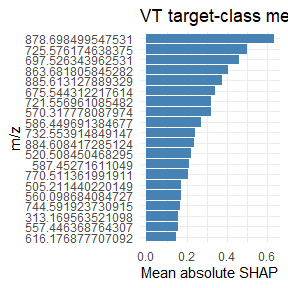

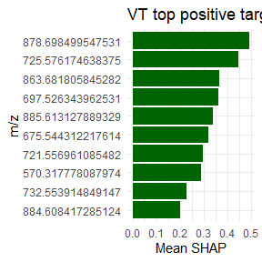

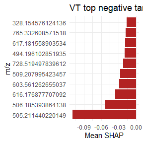

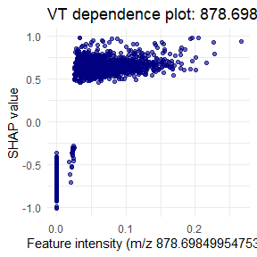

```r
if (ROI %in% names(roi_shap_results)) {
  active_shap <- roi_shap_results[[ROI]]

  mean_abs_shap <- sort(colMeans(abs(active_shap$target_shaps)), decreasing = TRUE)
  mean_pos_shap <- sort(
    active_shap$mean_target_shap[active_shap$mean_target_shap > 0],
    decreasing = TRUE
  )
  mean_neg_shap <- sort(
    active_shap$mean_target_shap[active_shap$mean_target_shap < 0],
    decreasing = FALSE
  )

  mean_abs_df <- data.frame(
    feature = names(head(mean_abs_shap, 20)),
    mean_abs_shap = as.numeric(head(mean_abs_shap, 20))
  )
  mean_pos_df <- data.frame(
    feature = names(head(mean_pos_shap, 10)),
    mean_shap = as.numeric(head(mean_pos_shap, 10))
  )
  mean_neg_df <- data.frame(
    feature = names(head(mean_neg_shap, 10)),
    mean_shap = as.numeric(head(mean_neg_shap, 10))
  )

  mean_abs_plot <- ggplot(
    mean_abs_df,
    aes(x = reorder(feature, mean_abs_shap), y = mean_abs_shap)
  ) +
    geom_col(fill = "steelblue") +
    coord_flip() +
    labs(
      title = paste0(ROI, " target-class mean |SHAP|"),
      x = "m/z",
      y = "Mean absolute SHAP"
    ) +
    theme_minimal()

  mean_pos_plot <- ggplot(
    mean_pos_df,
    aes(x = reorder(feature, mean_shap), y = mean_shap)
  ) +
    geom_col(fill = "darkgreen") +
    coord_flip() +
    labs(
      title = paste0(ROI, " top positive target-class SHAP"),
      x = "m/z",
      y = "Mean SHAP"
    ) +
    theme_minimal()

  mean_neg_plot <- ggplot(
    mean_neg_df,
    aes(x = reorder(feature, mean_shap), y = mean_shap)
  ) +
    geom_col(fill = "firebrick") +
    coord_flip() +
    labs(
      title = paste0(ROI, " top negative target-class SHAP"),
      x = "m/z",
      y = "Mean SHAP"
    ) +
    theme_minimal()

  print(mean_abs_plot)
  print(mean_pos_plot)
  print(mean_neg_plot)

  ggsave(
    filename = file.path(
      active_shap$roi_output_dir,
      paste0(ROI, "_target_class_mean_abs_shap.png")
    ),
    plot = mean_abs_plot,
    width = 10,
    height = 6,
    dpi = 300
  )
  ggsave(
    filename = file.path(
      active_shap$roi_output_dir,
      paste0(ROI, "_target_class_positive_shap.png")
    ),
    plot = mean_pos_plot,
    width = 10,
    height = 6,
    dpi = 300
  )
  ggsave(
    filename = file.path(
      active_shap$roi_output_dir,
      paste0(ROI, "_target_class_negative_shap.png")
    ),
    plot = mean_neg_plot,
    width = 10,
    height = 6,
    dpi = 300
  )

  dependence_feature <- if (nrow(mean_pos_df) > 0) {
    mean_pos_df$feature[[1]]
  } else {
    mean_abs_df$feature[[1]]
  }

  dependence_df <- data.frame(
    feature_value = active_shap$target_values[[dependence_feature]],
    shap_value = active_shap$target_shaps[, dependence_feature],
    feature = dependence_feature
  )

  dependence_plot <- ggplot(
    dependence_df,
    aes(x = feature_value, y = shap_value)
  ) +
    geom_point(alpha = 0.6, color = "navy") +
    labs(
      title = paste0(ROI, " dependence plot: ", dependence_feature),
      x = paste0("Feature intensity (m/z ", dependence_feature, ")"),
      y = "SHAP value"
    ) +
    theme_minimal()

  print(dependence_plot)

  ggsave(
    filename = file.path(
      active_shap$roi_output_dir,
      paste0(ROI, "_target_class_dependence_", dependence_feature, ".png")
    ),
    plot = dependence_plot,
    width = 10,
    height = 6,
    dpi = 300
  )
} else {
  message("No eligible SHAP result available for the active ROI: ", ROI)
}
```

# SHAP filter application

use `SIFS::Zero_remover()` method

```r
# [01] get SHAP csv files you need:
SHAP_csvNames = list.files(file.path(AbsPath,"output/SHAP_outputs/"), pattern = ".csv", full.names = TRUE, recursive = TRUE)

if(SelSHAP == "PosSHAP"){
      SHAP_files = grepl(x= SHAP_csvNames,pattern  = "PostiveSHAP_")
}else {
      SHAP_files = grepl(x= SHAP_csvNames,pattern  = "NegativeSHAP_")}

ShapFiles = SHAP_csvNames[SHAP_files]

# this example only has VT and Nec in the training set tissue sample, adjust accordingly:

VT_shap_csv  = ShapFiles[grepl(x =  ShapFiles, pattern = "_VT_")]
Nec_shap_csv = ShapFiles[grepl(x =  ShapFiles, pattern = "_Nec_")]
# Read the SHAP values df:
VT_shap_df  = data.table::fread(VT_shap_csv)
Nec_shap_df = data.table::fread(Nec_shap_csv)
# PreNec_shap_df = data.table::fread(PreNec_shap_csv) # in case other ROIs existed in the tissue! add them like so.

VT_shap_df_Sorted = VT_shap_df[order(
      as.numeric(VT_shap_df[[1]]), decreasing = FALSE
      )
      ]

Nec_shap_csv_Sorted = Nec_shap_df[order(
      as.numeric(Nec_shap_df[[1]]), decreasing = FALSE
      )
      ]



# SHAP values per class in 1 df:
SHAP_df = cbind(VT_shap_df_Sorted, Nec_shap_csv_Sorted)

colnames(SHAP_df) = c("mzList", paste0(ROIs[1],"_SHAP"), "mzList_2",paste0(ROIs[2],"_SHAP") )

SHAP_df = SHAP_df[, -c("mzList_2")]
SHAP_df = as.data.table(SHAP_df)

cols_to_check <- 2:3
mat <- as.matrix(SHAP_df[, ..cols_to_check])
SHAP_df_zeroRM <- SHAP_df[rowSums(mat) != 0]

# yields a dimension of (1359 X  3) removing 89.7% of the features.
```

# Assign SHAP to class:

- this is feature assignment:

```r
# max feature value for class:
max_feat <- apply(SHAP_df_zeroRM[, c(2,3)], MARGIN = 1, FUN = function(row){
      names(SHAP_df_zeroRM)[which.max(row)+1]
      })

SHAP_df_zeroRM$"max_feat" <- max_feat

# Feature assignment to class (based on SHAP):
mz_VT_shap_assigned  <- SHAP_df_zeroRM[which(SHAP_df_zeroRM$max_feat == "VT_SHAP"), ]
mz_VT_shap_assigned <- mz_VT_shap_assigned[order(mz_VT_shap_assigned$VT_SHAP, decreasing = TRUE), ]
mz_Nec_shap_assigned <- SHAP_df_zeroRM[which(SHAP_df_zeroRM$max_feat != "VT_SHAP"), ]
mz_Nec_shap_assigned <- mz_Nec_shap_assigned[order(mz_Nec_shap_assigned$Nec_SHAP, decreasing = TRUE)]
```

## Run HMCS method sourced from methods

use `SIFS::HMCS_calculatorBinary()` method from SIFS package.

this requires:

- spatial windows, depends on `moleculaR` pacakge:
- precalculated FWHM

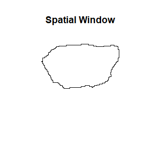

```r
# create SPWIN object for each tissue sample:
if (!exists("t3_spmat_pos")) {
  t3_spmat_pos <- readRDS(file = file.path(checkPointDir, "data/input/01_spmatObjects/trainset_tissue/tr_spmat_XIII_t3_83318.rds"))
}
if (!exists("t4_spmat_pos")) {
  t4_spmat_pos <- readRDS(file = file.path(checkPointDir, "data/input/01_spmatObjects/testset_tissue/tst_spmat_XV_t1_82558.rds"))
}

spwin_t3 <- moleculaR::createSpatialWindow(pixelCoords = t3_spmat_pos$coordinates, plot = T)
```

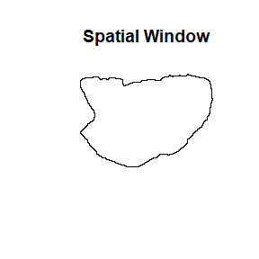

```r
spwin_t4 <- moleculaR::createSpatialWindow(pixelCoords = t4_spmat_pos$coordinates, plot = T)
```

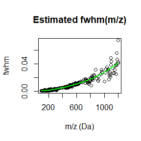

```r
fwhm_pos <- readRDS(file.path(checkPointDir,"data/input/06_fwhm_object/fwhm_obj_pos.rds"))
plot(fwhm_pos)
```

## Select ROI, here would be VT

```r
# below gets m/z list for the ROI of focus to test HMCS:
if(ROI ==ROIs[1]){
      mzList <- mz_VT_shap_assigned$mzList
} else if(ROI ==ROIs[2]){
      mzList <- mz_Nec_shap_assigned$mzList
} else{
      cat("Add the other ROI conditions here!")
      }
# Note: these are arranged from highest (positive) SHAP values to lowest.
print(mzList[1:10])
```

```
#>  [1] 878.6985 725.5762 863.6818 697.5263 675.5443 721.5570 570.3178 732.5539
#>  [9] 884.6084 520.5085
```

# SPP and MPM calculation on Training set tissue sample(s)

```r
## SPP calcualtion per tissue:
SPP_t3_list_pos <- NULL
SPP_t4_list_pos <- NULL
hotspotMasks_t3 <- NULL
hotspotMasks_t4 <- NULL
probImg_t3_pos  <- NULL
probImg_t4_pos  <- NULL

for(i in seq_along(mzList)){
      # calculation of SPP for t3:
      SPP_t3_list_pos <- moleculaR::searchAnalyte(m = mzList[[i]],
                                                  fwhm = moleculaR::getFwhm(fwhm_pos, mzList[i]),
                                                  spwin = spwin_t3,
                                                  spData = t3_spmat_pos,
                                                  wMethod = "Gaussian"
                                                  )
      # Check if any analyte was found
      if (SPP_t3_list_pos$n > 0) {
            # If analyte was found, calculate the probability map
            tissue3_MPMObj <- moleculaR::probMap(sppMoi = SPP_t3_list_pos, bw = 2.5)
            # Store the probability map in the results list
            probImg_t3_pos[[i]] <-tissue3_MPMObj
            hotspotMasks_t3[[i]] <- probImg_t3_pos[[i]]$hotspotMask
      }





      # calculation of SPP for t4:
      SPP_t4_list_pos <- moleculaR::searchAnalyte(m = mzList[[i]],
                                                  fwhm = moleculaR::getFwhm(fwhm_pos, mzList[i]),
                                                  spwin = spwin_t4,
                                                  spData = t4_spmat_pos,
                                                  wMethod = "Gaussian"
      )
      # Check if any analyte was found
      if (SPP_t4_list_pos$n > 0) {
            # If analyte was found, calculate the probability map
            tissue4_MPMObj <- moleculaR::probMap(sppMoi = SPP_t4_list_pos, bw = 2.5)
            # Store the probability map in the results list
            probImg_t4_pos[[i]] <-tissue4_MPMObj

            hotspotMasks_t4[[i]] <-probImg_t4_pos[[i]]$hotspotMask}      }
```

[output not shown]

[output cut: 2086 more lines]

[output not shown]

## Save SPP and MPM objects

```r
# Creates a list containing all SPP and MPM objects to be saved locally and referenced later:
SPP_MPM_objects <- list(SPP_t3 = SPP_t3_list_pos,
                        SPP_t4 = SPP_t4_list_pos,
                        MPM_t3 = probImg_t3_pos,
                        MPM_t4 = probImg_t4_pos
                        )

dir.create(file.path(checkPointDir, "output/SPPs_MPMs"), recursive = TRUE, showWarnings = FALSE)
saveRDS(object = SPP_MPM_objects, file = file.path(checkPointDir, "output/SPPs_MPMs", "01_spp_mpm_objects.rds"))
# readRDS(file = file.path("output/SPPs_MPMs", "01_spp_mpm_objects.rds"))
```

### Output quality checks:

```r
cat("Running a quality check for the first m/z value's hotspot maps: ")
```

```
#> Running a quality check for the first m/z value's hotspot maps:
```

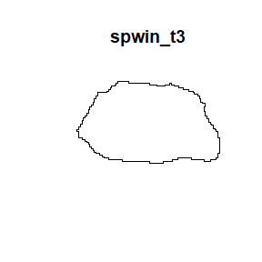

```r
plot(spwin_t3)
```

```r
library(moleculaR)
moleculaR:::plot.molProbMap(probImg_t3_pos[[1]], what = "MPM", figLegend = FALSE)
```

[output not shown]

### Calculate overlap:

step 1) create empty slots:

```r
# Initiate a list object to contain patient ids:
# Create an empty list to store dsc_objs - using t3 (training) and t4 (testing)
tissues_list <- c("t3", "t4")
dsc_objs <- vector(mode = "list", length = length(tissues_list))
names(dsc_objs) <- tissues_list

for(i in seq_along(dsc_objs)){
      dsc_objs[[i]]$dcs_with_VT      <- vector(mode = "list")
      # dsc_objs[[i]]$dcs_with_VtVasc  <- vector(mode = "list")
      dsc_objs[[i]]$dcs_with_Nec     <- vector(mode = "list")
      # dsc_objs[[i]]$dcs_with_PreNec  <- vector(mode = "list")
      }

# Initialize mpm_htspt_win before DSC calculation
if (length(hotspotMasks_t3) > 0 && !is.null(hotspotMasks_t3[[1]])) {
  mpm_htspt_win <- list(t3 = hotspotMasks_t3)
} else {
  mpm_htspt_win <- list(t3 = list())
  message("Warning: No hotspot masks found for t3")
}
```

```r
# [01] Training tissue DSC pbjects:
# loop through VT t3:

for (i in seq_along(dsc_objs$t3)) {
        dsc_objs$t3$dcs_with_VT <- tryCatch(
          {
            lapply(X = mpm_htspt_win$t3, FUN = function(X) {
              if(!is.null(master_windows$t3$VT_win)){
                    moleculaR::dsc(win0 = X,
                                   win1 = master_windows$t3$VT_win,
                                   winBackground = spwin_t3,
                                   plot = F  # "T" replaced with "TRUE"
                                   )

              } else {
                print(master_windows$t3$VT_win)
              }
            })
          },
          error = function(e) {
            message(paste("Error occurred for time point", i, ": ", conditionMessage(e)))
            return(NULL)  # Return NULL if an error occurs
          }
        )
      }
```

[output not shown]

```r
# loop through Nec T3:
for (i in seq_along(dsc_objs$t3)) {
        dsc_objs$t3$dcs_with_Nec <- tryCatch(
          {
            lapply(X = mpm_htspt_win$t3, FUN = function(X) {
              if(!is.null(master_windows$t3$Nec_win)){
                    moleculaR::dsc(win0 = X,
                                   win1 = master_windows$t3$Nec_win,
                                   winBackground = spwin_t3,
                                   plot = F  # "T" replaced with "TRUE"
                                   )

              } else {
                print(master_windows$t3$Nec_win)
              }
            })
          },
          error = function(e) {
            message(paste("Error occurred for time point", i, ": ", conditionMessage(e)))
            return(NULL)  # Return NULL if an error occurs
          }
        )
      }
```

[output not shown]

```r
# loop through PreNec T3:
#
# for (i in seq_along(dsc_objs$t3)) {
#         dsc_objs$t3$dcs_with_PreNec <- tryCatch(
#           {
#             lapply(X = mpm_htspt_win$t3, FUN = function(X) {
#               if(!is.null(master_windows$t3$PreNec_win)){
#                     moleculaR::dsc(win0 = X,
#                                    win1 = master_windows$t3$PreNec_win,
#                                    winBackground = spwin_list$t3,
#                                    plot = F  # "T" replaced with "TRUE"
#                                    )
#
#               } else {
#                 print(master_windows$t3$PreNec_win)
#               }
#             })
#           },
#           error = function(e) {
#             message(paste("Error occurred for time point", i, ": ", conditionMessage(e)))
#             return(NULL)  # Return NULL if an error occurs
#           }
#         )
#       }


# DSC DF of trainingset
dsc_df <- data.frame(
  mzList = mzList,
  dsc_mpm_VT  = NA_real_,
  dsc_mpm_Nec = NA_real_
)
if (length(hotspotMasks_t3) > 0 && !is.null(hotspotMasks_t3[[1]])) {
  if (length(unlist(dsc_objs$t3$dcs_with_VT)) == length(mzList)) {
    dsc_df$dsc_mpm_VT  <- unlist(dsc_objs$t3$dcs_with_VT)
    dsc_df$dsc_mpm_Nec <- unlist(dsc_objs$t3$dcs_with_Nec)
  } else {
    message("DSC calculation returned incomplete results")
  }
} else {
  message("No hotspot masks found, DSC values set to NA")
}
```

```
#> DSC calculation returned incomplete results
```

binary HMCS calcualtor:

```r
# [Date]   02.07.2025
# [Author] SHAD A. M.
# [Method] HMCS alculator binary mode.

HMCS_calculatorBinary <- function(DSC_df, focusROI = "VT", ...){
      # equation
      if(focusROI == "VT"){
            hmcs_VT <- (DSC_df$dsc_mpm_VT)- (DSC_df$dsc_mpm_Nec )#+ DSC_df$dsc_PreNec
            return(hmcs_VT)
      } else if(focusROI == "Nec"){
            hmcs_Nec <- (DSC_df$dsc_mpm_Nec)- (DSC_df$dsc_mpm_VT)# + DSC_df$dsc_PreNec
            return(hmcs_Nec)
      }


}
```